# Generosity and Partnership in Dictator and Impunity Games: An Experiment

Jeffrey Avedisian

## Abstract

This study investigates partnerships and generosity in economic games using social network analysis. The experiment utilizes three-player dictator and impunity games to measure generosity and explore the concept of homophily. The results show a significant increase in generosity in the impunity game compared to the dictator game, indicating the influence of the social distance imposed by the accept or reject mechanism. No evidence of generosity homophily is found in partner preference networks. Participants tend to avoid individuals who did not donate, but partner selection appears to be random. The study also reveals a transition from imperfect to perfect information significantly impacts player behavior and network reciprocity. Overall, the findings highlight the importance of being endowed with a voice in social settings and information in shaping cooperation and decision-making in economic games.

## Introduction

This document will serve as supplementary information for the data analysis portion of the thesis.

### Data Upload

Packages are uploaded and then the master data file is uploaded from the GitHub repository.

```r
library(tidyverse)
library(statnet)
```

```r
library(homophily)
library(ggplot2)
library(perm)
library(sandwich)
library(exactRankTests)
library(lmtest)
library(gtools)
library(vecsets)

load ("master.Rdata")
```

## First Look

Starting from the ‘Results’ section of the thesis, the first thing shown are some descriptive statistics.

### Demographic Data

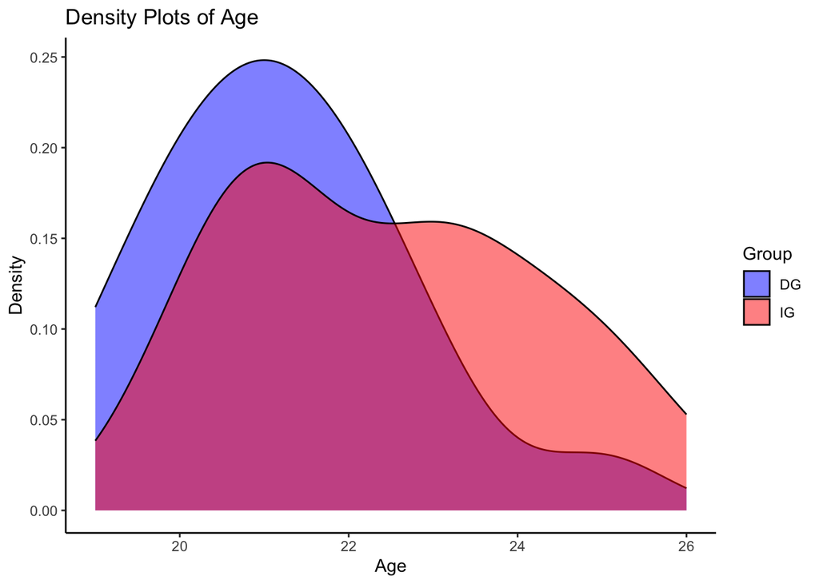

```r
theme_set(theme_classic())

dg.age <- dgdata$digames.1.player.age
ig.age <- igdata$digames.1.player.age

# Combine the factors into a data frame
agedata <- data.frame(Age = c(dg.age, ig.age),
                   Group = c(rep("DG", length(dg.age)), rep("IG", length(ig.age))))
# density plot
ggplot(agedata, aes(x = Age, fill = Group)) +
  geom_density(alpha = 0.5) +
  labs(x = "Age", y = "Density", title = "Density Plots of Age") +
  scale_fill_manual(values = c("DG" = "blue", "IG" = "red"))
```

### Political Views

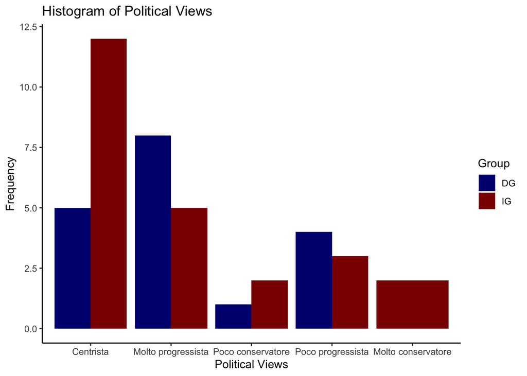

```r
dg.pol <- as.factor(dgdata$digames.1.player.opinions)
ig.pol <- as.factor(igdata$digames.1.player.opinions)

# Combine the factors into a data frame
poldata <- data.frame(Category = c(dg.pol, ig.pol),
                   Group = c(rep("DG", length(dg.pol)), rep("IG", length(ig.pol))))

# Create a histogram using ggplot2
ggplot(poldata, aes(x = Category, fill = Group)) +
  geom_bar(position = "dodge") +
  labs(x = "Political Views", y = "Frequency", title = "Histogram of Political Views") +
  scale_fill_manual(values = c("DG" = "navyblue", "IG" = "darkred"))
```

Now observe the average $\alpha$ and $\beta$ over time.

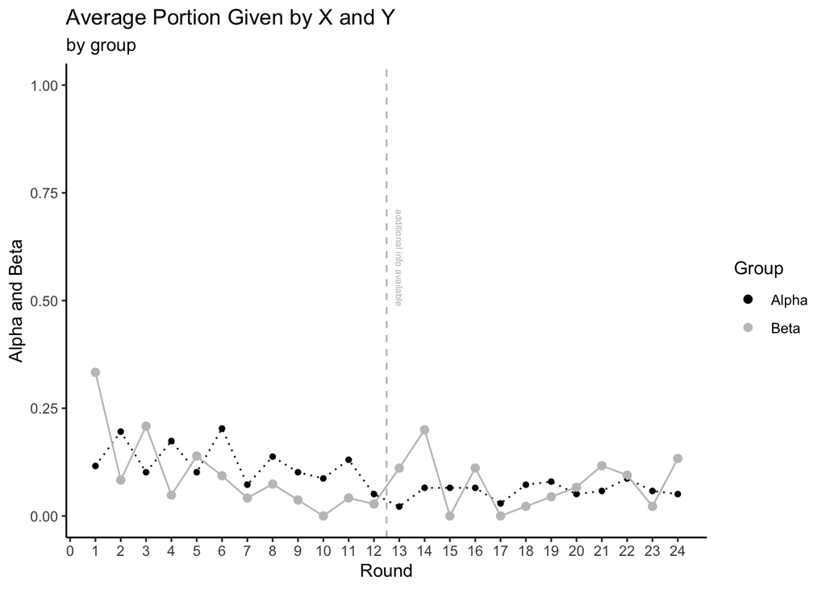

```r
# set theme
theme_set(theme_classic())

# plot of alpha and beta over time for DG and IG
dg.abplot
```

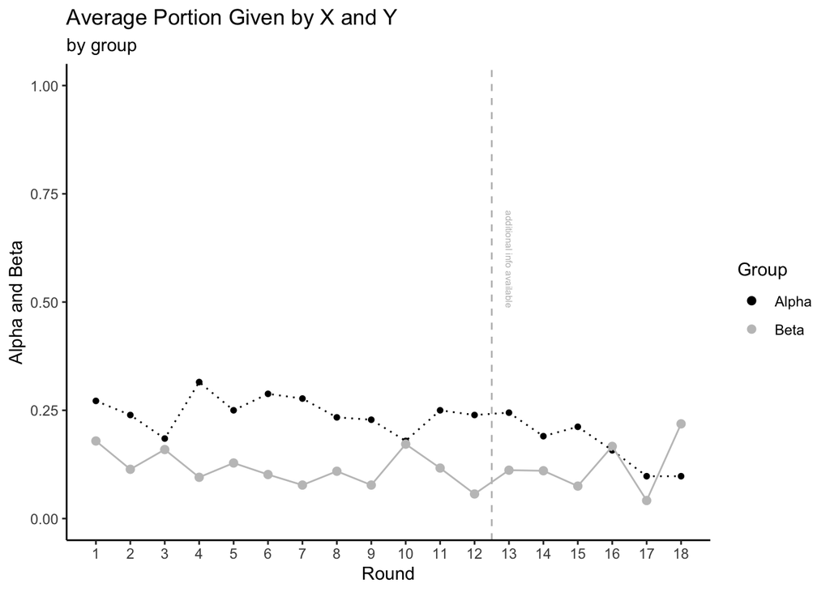

```r
ig.abplot
```

A look at rejection behavior.

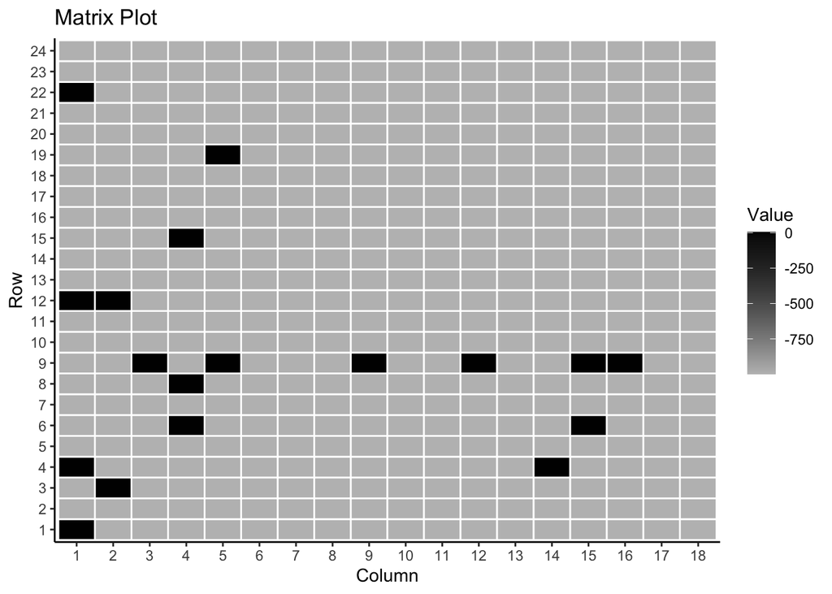

```r
# Create row and column indices
row_indices <- row(rejoff)
col_indices <- col(rejoff)

# Convert matrix to data frame
rejdata <- data.frame(Row = as.factor(row_indices),
                   Column = as.factor(col_indices),
                   Value = as.vector(rejoff))

# Create a matrix plot using ggplot2
ggplot(rejdata, aes(x = Column, y = Row, fill = Value)) +
  geom_tile(color = "white", size = 0.5) +
  scale_fill_gradient(low = "grey", high = "black", na.value = "white") +
  labs(x = "Column", y = "Row", title = "Matrix Plot")
```

The end.